# Getting Started with kerasnip

## The Core Idea: From Keras Layers to Tidymodels Specs

The `keras3` package allows for building deep learning models layer-by-layer, which is a powerful and flexible approach. However, the `tidymodels` ecosystem is designed around declarative model specifications, where you define *what* model you want and which of its parameters you want to tune, rather than building it imperatively.

`kerasnip` bridges this gap with a simple but powerful concept: **layer blocks**. You define the components of your neural network (e.g., an input block, a dense block, a dropout block) as simple R functions. `kerasnip` then uses these blocks as building materials to create a brand new `parsnip` model specification function for you.

This new function behaves just like any other `parsnip` model (e.g., `rand_forest()` or `linear_reg()`), making it easy to integrate into `tidymodels` workflows.

## Installation

You can install the development version of `kerasnip` from GitHub. You will also need `keras3`.

```r
install.packages("pak")
pak::pak("davidrsch/kerasnip")
pak::pak("rstudio/keras3")

# Install the backend
keras3::install_keras()
```

We’ll start by loading `kerasnip`, `tidymodels` and `keras3`:

```r
library(kerasnip)
library(tidymodels)
library(keras3)
```

## A `kerasnip` MNIST Example

Let’s replicate the classic Keras introductory example, training a simple MLP on the MNIST dataset, but using the `kerasnip` workflow. This will demonstrate how to translate a standard Keras model into a reusable, modular `parsnip` specification.

If you’re familiar with Keras, you’ll recognize the structure; if not, this is a perfect place to start. We’ll begin by learning the basics through a simple task: recognizing handwritten digits from the MNIST dataset.

The MNIST dataset contains 28×28 pixel grayscale images of handwritten digits, like these:

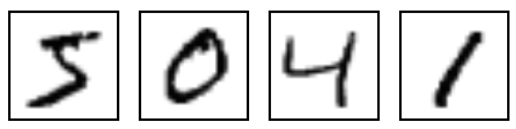

MINIST

Each image comes with a label indicating which digit it represents. For example, the labels for the images above might be 5, 0, 4, and 1.

### Preparing the Data

This step is identical to any other Keras model. We load the MNIST dataset, reshape the predictors, and convert the outcome to a factor for `tidymodels`.

```r
mnist <- dataset_mnist()
x_train <- mnist$train$x
y_train <- mnist$train$y
x_test <- mnist$test$x
y_test <- mnist$test$y

# Reshape
x_train <- array_reshape(x_train, c(nrow(x_train), 784))
x_test <- array_reshape(x_test, c(nrow(x_test), 784))
# Rescale
x_train <- x_train / 255
x_test <- x_test / 255

# Convert outcomes to factors for tidymodels
# kerasnip will handle y convertion internally using keras3::to_categorical()
y_train_factor <- factor(y_train)
y_test_factor <- factor(y_test)

# For tidymodels, it's best to work with data frames
# Use I() to keep the matrix structure of x within the data frame
train_df <- data.frame(x = I(x_train), y = y_train_factor)
test_df <- data.frame(x = I(x_test), y = y_test_factor)
```

### The Standard Keras Approach (for comparison)

Before diving into the `kerasnip` workflow, let’s quickly look at how this same model is built using standard `keras3` code. This will help highlight the different approach `kerasnip` enables.

```r
# The standard Keras3 approach
model <- keras_model_sequential(input_shape = 784) |>
  layer_dense(units = 256, activation = "relu") |>
  layer_dropout(rate = 0.4) |>
  layer_dense(units = 128, activation = "relu") |>
  layer_dropout(rate = 0.3) |>
  layer_dense(units = 10, activation = "softmax")

summary(model)

model |>
  compile(
    loss = "categorical_crossentropy",
    optimizer = optimizer_rmsprop(),
    metrics = "accuracy"
  )

# The model would then be trained with model |> fit(...)
```

The code above is imperative: you define each layer and add it to the model step-by-step. Now, let’s see how `kerasnip` approaches this by defining reusable components for a declarative, `tidymodels`-friendly workflow.

### Defining the Model with Reusable Blocks

The original Keras example interleaves `layer_dense()` and `layer_dropout()`. With `kerasnip`, we can encapsulate this pattern into a single, reusable block. This makes the overall architecture cleaner and more modular.

```r
# An input block to initialize the model.
# The 'model' argument is supplied implicitly by the kerasnip backend.
mlp_input_block <- function(model, input_shape) {
  keras_model_sequential(input_shape = input_shape)
}

# A reusable "module" that combines a dense layer and a dropout layer.
# All arguments that should be tunable need a default value.
dense_dropout_block <- function(model, units = 128, rate = 0.1) {
  model |>
    layer_dense(units = units, activation = "relu") |>
    layer_dropout(rate = rate)
}

# The output block for classification.
mlp_output_block <- function(model, num_classes) {
  model |> layer_dense(units = num_classes, activation = "softmax")
}
```

Now, we use `create_keras_sequential_spec()` to generate our `parsnip` model function.

```r
create_keras_sequential_spec(
  model_name = "mnist_mlp",
  layer_blocks = list(
    input = mlp_input_block,
    hidden_1 = dense_dropout_block,
    hidden_2 = dense_dropout_block,
    output = mlp_output_block
  ),
  mode = "classification"
)
```

### Building and Fitting the Model

We can now use our new `mnist_mlp()` function. Notice how its arguments, such as `hidden_1_units` and `hidden_1_rate`, were automatically generated by `kerasnip`. The names are created by combining the name of the layer block (e.g., `hidden_1`) with the arguments of that block’s function (e.g., `units`, `rate`).

To replicate the `keras3` example, we’ll use both `hidden` blocks and provide their parameters.

```r
mlp_spec <- mnist_mlp(
  hidden_1_units = 256,
  hidden_1_rate = 0.4,
  hidden_2_rate = 0.3,
  hidden_2_units =  128,
  compile_loss = "categorical_crossentropy",
  compile_optimizer = optimizer_rmsprop(),
  compile_metrics = c("accuracy"),
  fit_epochs = 30,
  fit_batch_size = 128,
  fit_validation_split = 0.2
) |>
  set_engine("keras")

# Fit the model
mlp_fit <- fit(mlp_spec, y ~ x, data = train_df)
```

```
#> 1875/1875 - 5s - 3ms/step
```

```r
mlp_fit |>
  extract_keras_model() |>
  summary()
```

```
#> Model: "sequential"
#> ┏━━━━━━━━━━━━━━━━━━━━━━━━━━━━━━━━━━━━━━━━━━━━━━━━━━━━━┳━━━━━━━━━━━━━━━━━━━━━━━━━━━━━━━━━━━━━━━━┳━━━━━━━━━━━━━━━━━━━━━━━┓
#> ┃ Layer (type)                                        ┃ Output Shape                           ┃               Param # ┃
#> ┡━━━━━━━━━━━━━━━━━━━━━━━━━━━━━━━━━━━━━━━━━━━━━━━━━━━━━╇━━━━━━━━━━━━━━━━━━━━━━━━━━━━━━━━━━━━━━━━╇━━━━━━━━━━━━━━━━━━━━━━━┩
#> │ dense (Dense)                                       │ (None, 256)                            │               200,960 │
#> ├─────────────────────────────────────────────────────┼────────────────────────────────────────┼───────────────────────┤
#> │ dropout (Dropout)                                   │ (None, 256)                            │                     0 │
#> ├─────────────────────────────────────────────────────┼────────────────────────────────────────┼───────────────────────┤
#> │ dense_1 (Dense)                                     │ (None, 128)                            │                32,896 │
#> ├─────────────────────────────────────────────────────┼────────────────────────────────────────┼───────────────────────┤
#> │ dropout_1 (Dropout)                                 │ (None, 128)                            │                     0 │
#> ├─────────────────────────────────────────────────────┼────────────────────────────────────────┼───────────────────────┤
#> │ dense_2 (Dense)                                     │ (None, 10)                             │                 1,290 │
#> └─────────────────────────────────────────────────────┴────────────────────────────────────────┴───────────────────────┘
#>  Total params: 470,294 (1.79 MB)
#>  Trainable params: 235,146 (918.54 KB)
#>  Non-trainable params: 0 (0.00 B)
#>  Optimizer params: 235,148 (918.55 KB)
```

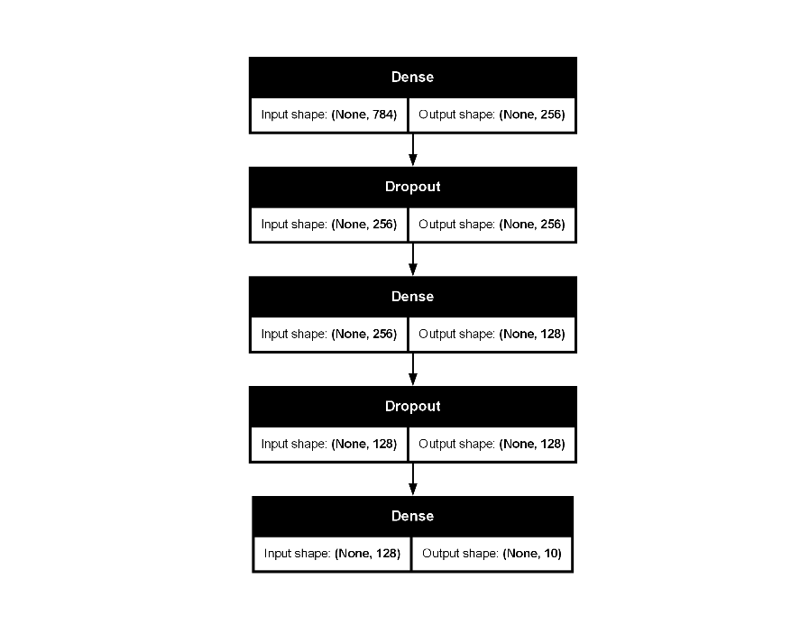

model

```r
mlp_fit |>
  extract_keras_model() |>
  plot(show_shapes = TRUE)
```

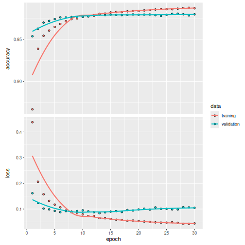

```r
mlp_fit |>
  extract_keras_history() |>
  plot()
```

### Evaluating Model Performance

The `keras_evaluate()` function provides a straightforward way to assess the model’s performance on a test set, using the underlying `keras3::evaluate()` method. It returns the loss and any other metrics that were specified during the model compilation step.

```r
mlp_fit |> keras_evaluate(x_test, y_test)
```

```
#> 313/313 - 1s - 3ms/step - accuracy: 0.9817 - loss: 0.0886
#> $accuracy
#> [1] 0.9817
#>
#> $loss
#> [1] 0.08861916
```

### Making Predictions

Once the model is trained, we can use the standard `tidymodels` `predict()` function to generate predictions on new data. By default, `predict()` on a `parsnip` classification model returns the predicted class labels.

```r
# Predict the class for the first 5 images in the test set
class_preds <- mlp_fit |>
  predict(new_data = head(select(test_df, x)))
```

```
#> 1/1 - 0s - 81ms/step
```

```r
class_preds
```

```
#> # A tibble: 6 × 1
#>   .pred_class
#>   <fct>
#> 1 7
#> 2 2
#> 3 1
#> 4 0
#> 5 4
#> 6 1
```

To get the underlying probabilities for each class, we can set `type = "prob"`. This returns a tibble with a probability column for each of the 10 classes (0-9).

```r
# Predict probabilities for the first 5 images
prob_preds <- mlp_fit |>
  predict(new_data = head(select(test_df, x)), type = "prob")
```

```
#> 1/1 - 0s - 42ms/step
```

```r
prob_preds
```

```
#> # A tibble: 6 × 10
#>    .pred_0   .pred_1  .pred_2  .pred_3   .pred_4  .pred_5  .pred_6  .pred_7  .pred_8  .pred_9
#>      <dbl>     <dbl>    <dbl>    <dbl>     <dbl>    <dbl>    <dbl>    <dbl>    <dbl>    <dbl>
#> 1 2.62e-21 1.07 e-15 7.46e-12 4.47e-14 2.44 e-18 4.68e-18 3.09e-27 1   e+ 0 7.03e-19 3.15e-14
#> 2 1.76e-18 5.11 e-10 1   e+ 0 8.01e-14 1.14 e-22 1.08e-20 2.28e-16 5.92e-17 7.76e-18 1.22e-28
#> 3 1.06e-13 1.000e+ 0 3.65e- 9 1.31e-11 9.77 e- 9 2.49e-10 9.61e-10 3.67e- 7 2.34e- 9 2.54e-13
#> 4 1   e+ 0 3.67 e-17 1.04e- 9 5.76e-12 2.73 e-12 3.62e-11 7.92e-10 9.28e-12 3.18e-13 4.39e-10
#> 5 1.42e-12 3.82 e-13 5.75e-10 8.42e-14 1.000e+ 0 2.95e-11 1.51e-11 1.11e- 7 1.48e-11 1.56e- 6
#> 6 8.40e-14 1.000e+ 0 4.06e-10 4.94e-12 1.40 e- 9 3.10e-11 7.30e-11 1.84e- 7 1.35e-10 9.70e-14
```

We can then compare the predicted class to the actual class for these images to see how the model is performing.

```r
# Combine predictions with actuals for comparison
comparison <- bind_cols(
  class_preds,
  prob_preds
) |>
  bind_cols(
    head(test_df[, "y", drop = FALSE])
  )
comparison
```

```
#> # A tibble: 6 × 12
#>   .pred_class  .pred_0   .pred_1  .pred_2  .pred_3   .pred_4  .pred_5  .pred_6  .pred_7  .pred_8  .pred_9 y
#>   <fct>          <dbl>     <dbl>    <dbl>    <dbl>     <dbl>    <dbl>    <dbl>    <dbl>    <dbl>    <dbl> <fct>
#> 1 7           2.62e-21 1.07 e-15 7.46e-12 4.47e-14 2.44 e-18 4.68e-18 3.09e-27 1   e+ 0 7.03e-19 3.15e-14 7
#> 2 2           1.76e-18 5.11 e-10 1   e+ 0 8.01e-14 1.14 e-22 1.08e-20 2.28e-16 5.92e-17 7.76e-18 1.22e-28 2
#> 3 1           1.06e-13 1.000e+ 0 3.65e- 9 1.31e-11 9.77 e- 9 2.49e-10 9.61e-10 3.67e- 7 2.34e- 9 2.54e-13 1
#> 4 0           1   e+ 0 3.67 e-17 1.04e- 9 5.76e-12 2.73 e-12 3.62e-11 7.92e-10 9.28e-12 3.18e-13 4.39e-10 0
#> 5 4           1.42e-12 3.82 e-13 5.75e-10 8.42e-14 1.000e+ 0 2.95e-11 1.51e-11 1.11e- 7 1.48e-11 1.56e- 6 4
#> 6 1           8.40e-14 1.000e+ 0 4.06e-10 4.94e-12 1.40 e- 9 3.10e-11 7.30e-11 1.84e- 7 1.35e-10 9.70e-14 1
```

## Example 2: Tuning the Model Architecture

Now we’ll showcase the main strength of `kerasnip`: tuning the network architecture itself. We can treat the number of layers, and the parameters of those layers, as hyperparameters to be optimized by `tune`.

Using the `mnist_mlp` spec we just created, let’s define a tunable model.

```r
# Define a tunable specification
# We set num_hidden_2 = 0 to disable the second hidden block
# for this tuning example
tune_spec <- mnist_mlp(
  num_hidden_1 = tune(),
  hidden_1_units = tune(),
  hidden_1_rate = tune(),
  num_hidden_2 = 0,
  compile_loss = "categorical_crossentropy",
  compile_optimizer = optimizer_rmsprop(),
  compile_metrics = c("accuracy"),
  fit_epochs = 30,
  fit_batch_size = 128,
  fit_validation_split = 0.2
) |>
  set_engine("keras")

# Create a workflow
tune_wf <- workflow(y ~ x, tune_spec)
```

Next, we define the search space for our tunable parameters using `dials`.

```r
# Define the tuning grid
params <- extract_parameter_set_dials(tune_wf) |>
  update(
    num_hidden_1 = dials::num_terms(c(1, 3)),
    hidden_1_units = dials::hidden_units(c(64, 256)),
    hidden_1_rate = dials::dropout(c(0.2, 0.4))
  )
grid <- grid_regular(params, levels = 3)
grid
```

```
#> # A tibble: 27 × 3
#>    num_hidden_1 hidden_1_units hidden_1_rate
#>           <int>          <int>         <dbl>
#>  1            1             64           0.2
#>  2            2             64           0.2
#>  3            3             64           0.2
#>  4            1            160           0.2
#>  5            2            160           0.2
#>  6            3            160           0.2
#>  7            1            256           0.2
#>  8            2            256           0.2
#>  9            3            256           0.2
#> 10            1             64           0.3
#> # ℹ 17 more rows
```

```r
# Using only the first 100 rows for speed. The real call
# should be: folds <- vfold_cv(train_df, v = 3)
folds <- vfold_cv(train_df[1:100, ], v = 3)

tune_res <- tune_grid(
  tune_wf,
  resamples = folds,
  grid = grid,
  metrics = metric_set(accuracy),
  control = control_grid(save_pred = FALSE, save_workflow = TRUE)
)
```

[output not shown]

[output cut: 107 more lines]

[output not shown]

Finally, we can inspect the results to find which architecture performed the best. First, a summary table:

```r
# Show the summary table of the best models
show_best(tune_res, metric = "accuracy")
```

```
#> # A tibble: 5 × 9
#>   num_hidden_1 hidden_1_units hidden_1_rate .metric  .estimator  mean     n std_err .config
#>          <int>          <int>         <dbl> <chr>    <chr>      <dbl> <int>   <dbl> <chr>
#> 1            3            256         0.400 accuracy multiclass 0.790     3  0.0312 pre0_mod27_post0
#> 2            1            256         0.2   accuracy multiclass 0.780     3  0.0281 pre0_mod07_post0
#> 3            2            160         0.400 accuracy multiclass 0.780     3  0.0281 pre0_mod15_post0
#> 4            3            160         0.3   accuracy multiclass 0.780     3  0.0281 pre0_mod23_post0
#> 5            3            256         0.3   accuracy multiclass 0.780     3  0.0281 pre0_mod26_post0
```

Now that we’ve identified the best-performing hyperparameters, our final step is to create and train the final model. We use `select_best()` to get the top parameters, `finalize_workflow()` to update our workflow with them, and then `fit()` one last time on our full training dataset.

```r
# Select the best hyperparameters
best_hps <- select_best(tune_res, metric = "accuracy")

# Finalize the workflow with the best hyperparameters
final_wf <- finalize_workflow(tune_wf, best_hps)

# Fit the final model on the full training data
final_fit <- fit(final_wf, data = train_df)
```

```
#> 1875/1875 - 3s - 1ms/step
```

We can now inspect our final, tuned model.

```r
# Print the model summary
final_fit |>
  extract_fit_parsnip() |>
  extract_keras_model() |>
  summary()
```

```
#> Model: "sequential_82"
#> ┏━━━━━━━━━━━━━━━━━━━━━━━━━━━━━━━━━━━━━━━━━━━━━━━━━━━━━┳━━━━━━━━━━━━━━━━━━━━━━━━━━━━━━━━━━━━━━━━┳━━━━━━━━━━━━━━━━━━━━━━━┓
#> ┃ Layer (type)                                        ┃ Output Shape                           ┃               Param # ┃
#> ┡━━━━━━━━━━━━━━━━━━━━━━━━━━━━━━━━━━━━━━━━━━━━━━━━━━━━━╇━━━━━━━━━━━━━━━━━━━━━━━━━━━━━━━━━━━━━━━━╇━━━━━━━━━━━━━━━━━━━━━━━┩
#> │ dense_246 (Dense)                                   │ (None, 256)                            │               200,960 │
#> ├─────────────────────────────────────────────────────┼────────────────────────────────────────┼───────────────────────┤
#> │ dropout_164 (Dropout)                               │ (None, 256)                            │                     0 │
#> ├─────────────────────────────────────────────────────┼────────────────────────────────────────┼───────────────────────┤
#> │ dense_247 (Dense)                                   │ (None, 256)                            │                65,792 │
#> ├─────────────────────────────────────────────────────┼────────────────────────────────────────┼───────────────────────┤
#> │ dropout_165 (Dropout)                               │ (None, 256)                            │                     0 │
#> ├─────────────────────────────────────────────────────┼────────────────────────────────────────┼───────────────────────┤
#> │ dense_248 (Dense)                                   │ (None, 256)                            │                65,792 │
#> ├─────────────────────────────────────────────────────┼────────────────────────────────────────┼───────────────────────┤
#> │ dropout_166 (Dropout)                               │ (None, 256)                            │                     0 │
#> ├─────────────────────────────────────────────────────┼────────────────────────────────────────┼───────────────────────┤
#> │ dense_249 (Dense)                                   │ (None, 10)                             │                 2,570 │
#> └─────────────────────────────────────────────────────┴────────────────────────────────────────┴───────────────────────┘
#>  Total params: 670,230 (2.56 MB)
#>  Trainable params: 335,114 (1.28 MB)
#>  Non-trainable params: 0 (0.00 B)
#>  Optimizer params: 335,116 (1.28 MB)
```

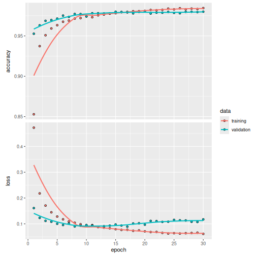

```r
# Plot the training history
final_fit |>
  extract_fit_parsnip() |>
  extract_keras_history() |>
  plot()
```

This result shows that `tune` has tested various network depths, widths, and dropout rates, successfully finding the best-performing combination within the search space. By using `kerasnip`, we were able to integrate this complex architectural tuning directly into a standard `tidymodels` workflow.